# Linear Regression

2026-04-07

## Outline

- We will start with the simplest case: univariate regression, and explain some details.
- The reason is that the multiple regression or generalized linear models often follow the same structure and …
- **Once you understand the `simple’ linear regression very well, the generalizations would be quite easy.**
- Some of the contents are taken from lecture notes on
- “Statistics for Social Sciences II: Multivariate Techniques” by Eduardo García Portugués and from
- “Introduction to Data Science: Data Analysis and Prediction Algorithms with R” by Rafael A. Irizarry.

## Example : PISA

- PISA is a study carried out by the OECD in 65 countries with the purpose of evaluating the performance of 15-year-old pupils on mathematics, science and reading.
- *Do wealthy countries tend to achieve larger average scores?*

> Q1. Is the educational level of a country influenced by its economic wealth?

> Q2. If so, up to what precise extent?

## Data

```r
pisa <- read.csv("datasets/pisa.csv")
str(pisa)
```

```
## 'data.frame':    65 obs. of  9 variables:
##  $ Country     : chr  "Shanghai-China" "Singapore" "Hong Kong SAR, China" "Chinese Taipei" ...
##  $ MathMean    : int  613 573 561 560 554 538 536 535 531 523 ...
##  $ MathShareLow: num  3.8 8.3 8.5 12.8 9.1 10.8 11.1 14.1 12.4 14.8 ...
##  $ MathShareTop: num  55.4 40 33.7 37.2 30.9 24.3 23.7 24.8 21.4 19.3 ...
##  $ ReadingMean : int  570 542 545 523 536 509 538 516 509 511 ...
##  $ ScienceMean : int  580 551 555 523 538 521 547 525 515 522 ...
##  $ GDPp        : num  6265 54451 36708 NA 24454 ...
##  $ logGDPp     : num  8.74 10.91 10.51 NA 10.1 ...
##  $ HighIncome  : logi  FALSE TRUE TRUE NA TRUE TRUE ...
```

## Linear regression

- The response variable: \(Y\) that we want to predict/explain.
- The explanatory variable (or predictor), denoted by \(X\) and is the variable used to predict/explain \(Y\)
- Recall the form of the linear model: \[ Y = \beta_0 + \beta_1 X + \epsilon \]
- In our case \(Y\) = `MathMean` and \(X\) = `logGDPp`

## First, make a plot

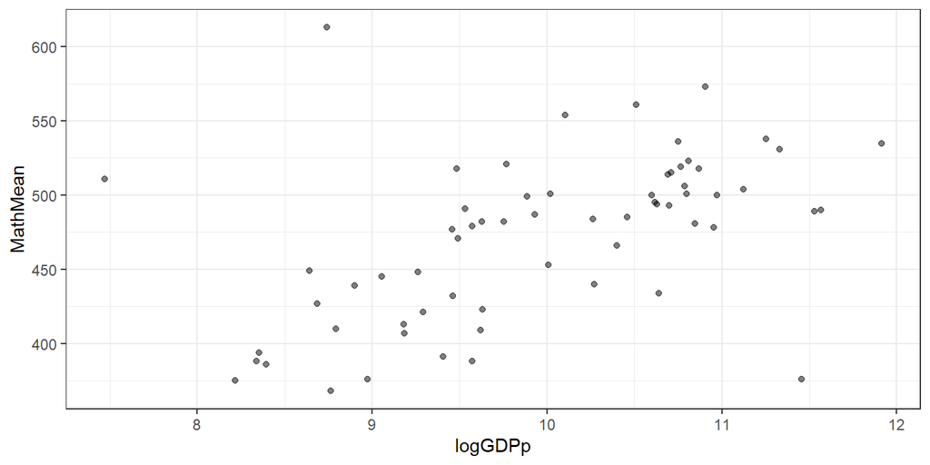

```r
library(ggplot2)
library(dplyr)
pisa %>% ggplot(aes(logGDPp,MathMean)) +
  geom_point(alpha = 0.5) + theme_bw()
```

## Linear model

```r
pisaLinearModel <- lm(MathMean ~ logGDPp, data = pisa)
summary(pisaLinearModel)
```

```
##
## Call:
## lm(formula = MathMean ~ logGDPp, data = pisa)
##
## Residuals:
##      Min       1Q   Median       3Q      Max
## -138.924  -29.109    1.381   20.239  176.166
##
## Coefficients:
##             Estimate Std. Error t value Pr(>|t|)
## (Intercept)   185.16      61.36   3.018  0.00369 **
## logGDPp        28.79       6.13   4.696 1.51e-05 ***
## ---
## Signif. codes:  0 '***' 0.001 '**' 0.01 '*' 0.05 '.' 0.1 ' ' 1
##
## Residual standard error: 47.48 on 62 degrees of freedom
##   (1 observation deleted due to missingness)
## Multiple R-squared:  0.2624, Adjusted R-squared:  0.2505
## F-statistic: 22.06 on 1 and 62 DF,  p-value: 1.512e-05
```

## Output

- The summary gives the coefficients of the line and the \(R^2\) (‘Multiple R-squared’), which can be regarded as an indicator of the strength of the linear relation between the variables.
- ( \(R^2 = 1\) is a perfect linear fit – all the points lay in a line – and \(R^2 = 0\) is the poorest fit.)
- The fitted regression line is:

`MathMean = 185.16 + 28.79×logGDPp`

- The slope coefficient is positive: there is a **positive correlation** between the wealth of a country and its performance in the PISA Mathematics test (Q1).
- More precise: increase of 1 unit in the `logGDPp` of a country is associated with achieving, on average, `28.79` additional points in the test (Q2).

## Correlation

- First we need a little review on concepts relating two random quantities, \(X\) and \(Y\).
- The correlation coefficient is defined for a list of pairs  
  \((x_1, y_1), \ldots, (x_n, y_n)\) as the average of the product of the standardized values:

\[ \rho = \frac{1}{n} \sum_{i=1}^{n} \left( \frac{x_i - \mu_x}{\sigma_x} \right) \left( \frac{y_i - \mu_y}{\sigma_y} \right) \]

- In R:

```r
rho <- mean(scale(x) * scale(y))
## or simply

rho <- cor(x,y)
```

- Correlation measures the strength of **linear** relationship.
- Correlation is always between -1 and +1

## Properties of correlation coefficient

- Always between -1 and +1, i.e. \(\lvert{\rho}\rvert \le 1\).
- Measures the **linear** relationship.
- In other words, \(\rho = 0\) implies no **linear** relationship.
- Also, if \(X\) and \(Y\) are independent, \(X \perp Y\), \(\rho(X,Y) = 0\).
- The converse of the above is not true, i.e. \(X\) and \(Y\) could be dependent but still have zero correlation.
- If \(\rho > 0\), there’s a positive **linear** relationship, and if \(\rho <0\) there is a negative **linear** relationship.

## How do they look like?

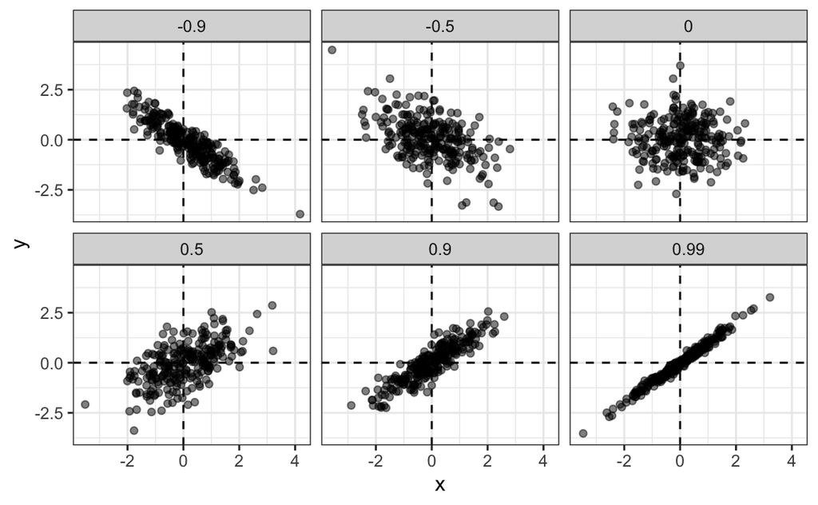

## Remember

- \(X\) and \(Y\) independent \(\Rightarrow\) \(\rho_{X,Y} = 0\), but not the other way round, unless \(X,Y\) are jointly normal.
- Correlation \(\not \Rightarrow\) Causation. There could be a **lurking** variable, causing a **spurious** relationship.
- Lots of hilarious examples in [Spurious Correlations Webpage](http://tylervigen.com/spurious-correlations)
- Example: Here \(\rho_{X,Y} = 0\), but \(Y = X^2\), not independent, but not **linearly dependent**.

```r
x = (-5:5)
y = x^2
cor(x,y)
```

```
## [1] 0
```

## “Linear” is the key word.

- Consider the following ‘fake’ data with a perfectly monotonically increasing relationship: \(y = x^4\)

```r
x = 1:7
y = x^4
cor(x,y)
```

```
## [1] 0.8903055
```

- The correlation is high but not equal to 1 despite the perfect relationship.
- The way to take care of this is via nonparametric correlation coefficients, such as Spearman’s rank correlation and Kendall’s \(\tau\).
- We will talk about both of them next time!

## Sample correlation is a random variable

- Before we continue connecting correlation to regression, let’s remind ourselves about random variability.
- Just like we have a sample mean \(\bar{X}\) as an estimator of the population mean \(\mu\), we can estimate \(\rho(X,Y)\), the population correlation coefficient by \(r(X,Y)\) the sample correlation coefficient.
- We do not observe data for the entire population of interest but rather for a random sample.
- As with the sample mean and the sample variance \(s^2\), the sample correlation is the most commonly used estimate of the population correlation.
- This implies that the correlation we compute and use as a summary is a random variable.

## Illustration

```r
pisa <- na.omit(pisa) ## removes the missing values
cor(pisa$MathMean, pisa$logGDPp)
```

```
## [1] 0.5122511
```

- Now suppose that the original data-set was the entire population, but you only have the data for \(25\) countries, not all of them.

```r
R <- sample_n(pisa, 25, replace = TRUE) %>%
  summarize(r = cor(MathMean, logGDPp)) %>% pull(r)
R
```

```
## [1] 0.458098
```

- If you select a different sample, you’ll get a different value!
- It is a random variable, and there must be a distribution!

## Monte Carlo

- Deriving the exact distribution of \(r_{xy}\) is quite difficult for a general bivariate population \((X,Y) \sim f(x,y)\).
- Fortunately, we can use Monte Carlo simulations to get a very good idea about it.
- The rough idea is that we will take MANY, MANY *resamples* from the same parent sample and calculate the quantity (\(r_{xy}\)) for each such sample and look at their distribution.
- This is a *powerful* tool and I will talk more about these tools (if and) when we talk about resampling strategies.

## Monte Carlo

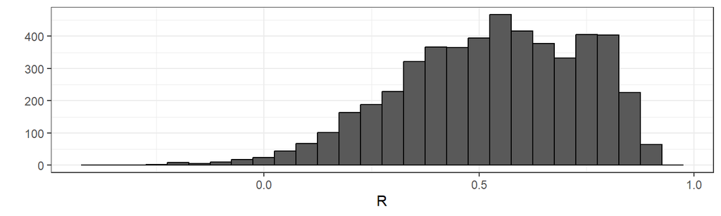

```r
B <- 5000
N <- 25
R <- replicate(B, {
  sample_n(pisa, N, replace = TRUE) %>%
    summarize(r=cor(MathMean, logGDPp)) %>%
    pull(r)
})
qplot(R, geom = "histogram", binwidth = 0.05, color = I("black")) + theme_bw()
```

## Sample correlation

- We see that the expected value of R is close to the population correlation:

```r
mean(R)
```

```
## [1] 0.5300971
```

- and that it has a relatively high standard error relative to the range of values R can take:

```r
sd(R)
```

```
## [1] 0.2114039
```

- So, when interpreting correlations, remember that correlations derived from samples are estimates containing uncertainty.

## CLT

- Also, note that because the sample correlation is an average of independent draws, the central limit actually applies.
- Therefore, for large enough \(N\), the distribution of R is approximately normal with expected value \(\rho\)
- The standard deviation, which is somewhat complex to derive, is \(\sqrt{\frac{1-r^2}{N-2}}\). We can still use this to test \(H_0: \rho = 0\).
- R has a simple way to test if a correlation value is significant.

```r
attach(pisa)
cor.test(MathMean, logGDPp)
```

```
##
##  Pearson's product-moment correlation
##
## data:  MathMean and logGDPp
## t = 4.6964, df = 62, p-value = 1.512e-05
## alternative hypothesis: true correlation is not equal to 0
## 95 percent confidence interval:
##  0.3048241 0.6732832
## sample estimates:
##       cor
## 0.5122511
```

## Permutation test

- You can also use the permutation test.
- The rough idea is that under moderate or strong dependence between the \(X\) and \(Y\), certain \(X_i\)’s are more likely to appear with certain \(Y_i\)’s, e.g. if \(\rho\) is high, large \(X\) will pair large \(Y\) values and vice versa.
- On the other hand, if \(\rho = 0\), all pairs are equally likely, i.e. a given \(Y_i\) is as likely to pair with the \(i^{th}\) observation \(X_i\) as it is with any other \(X_j\).
- In other words, all the \(n!\) permutations of \(Y_i\)’s with the \(X_i\)’s fixed-in-place are equally likely under the null: \(H_0: \rho = 0\).
- We can use this idea to implement the permutation test for testing significance of the correlation coefficient.

## Anscombe’s quartet

- Correlation is not always a good summary of the relationship between two variables.
- The following four artificial datasets, referred to as Anscombe’s quartet, famously illustrate this point. All these pairs have a correlation of 0.82.
- Also, look at the datasaurus dozen. https://jumpingrivers.github.io/datasauRus/

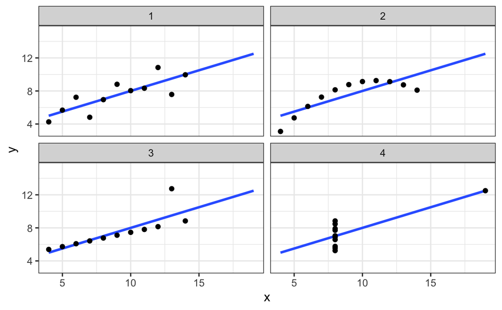

## Formulation

- Simple linear model: \(Y = \beta_0 + \beta_1 X + \epsilon\).
- \(\beta_0\) and \(\beta_1\) are known as the intercept and slope, and \(\epsilon\) is a random variable with mean zero and independent from \(X\).
- Another way of looking at this is: \[ \mathbb{E}(Y | X = x) = \beta_0 + \beta_1 X, \text{ since } \mathbb{E}(\epsilon | x) = 0. \]
- LHS: conditional expectation of \(Y\) given \(X\) : how the mean of the random variable \(Y\) is changing according to a particular value, denoted by \(x\), of the random variable \(X\).
- we are saying is that the mean of Y is changing in a linear fashion with respect to the value of X.

## Estimating \(\beta\)

- One way of estimating \((\beta_0, \beta_1)\) is by minimizing the residual sum of squares:

\[ RSS(\beta_0, \beta_1) = \sum_{i=1}^{n}(Y_i - \beta_0 - \beta_1 X_i) \]

- Look for estimates such that:

\[ (\hat{\beta}_0, \hat{\beta}_1) = \arg \min_{(\beta_0, \beta_1) \in \mathbb{R}^2} RSS(\beta_0, \beta_1) \] - It can be seen that the minimizers of the RSS are:

\[ \hat{\beta}_0 = \bar{Y} - \hat{\beta}_1 \bar{X}, \hat{\beta}_1 = \frac{s_{xy}}{s_{x}^2} \]

- \(\bar{X}, s_{xy}, s_{x}^2\): sample mean of \(Y\), covariance between \(X\) and \(Y\) and variance of \(X\) (\(s_x\) is the std. dev.)

## Check

```r
attach(pisa)
x <- logGDPp; y <- MathMean
# Covariance
Sxy <- cov(x,y)
# Variance
Sx2 <- var(x)
# Coefficients
beta1 <- Sxy / Sx2
beta0 <- mean(y) - beta1 * mean(x)
c(beta0, beta1)
```

```
## [1] 185.15788  28.78706
```

```r
# Output from lm
mod <- lm(MathMean ~ logGDPp, data = pisa)
mod$coefficients
```

```
## (Intercept)     logGDPp
##   185.15788    28.78706
```

## Other terms

- Fitted values: \(\hat{Y}_i = \hat{\beta}_0 + \hat\beta_1 X_i\). These are the vertical projections of \(Y_1, \ldots, Y_n\) into the fitted line.
- Residuals or estimated errors: \(\hat{\epsilon}_i = Y_i - \hat{Y}_i\). These are the vertical distances between actual data \((X_i, Y_i\) and fitted data \((X_i, \hat{Y}_i)\).

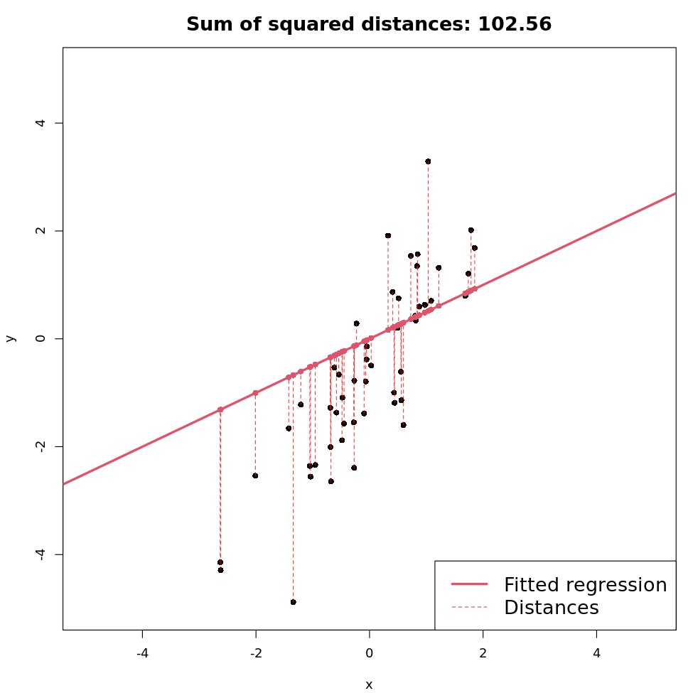

## Assumptions

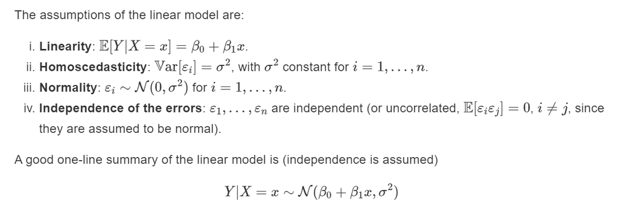

## Recall:

- Nothing is said about the distribution of \(X\) as yet. Indeed, \(X\) could be deterministic (called fixed design) or random (random design).
- The linear model assumes that \(Y\) is continuous due to the normality of the errors.
- However, \(X\) can be discrete!

## Assumptions (visually)

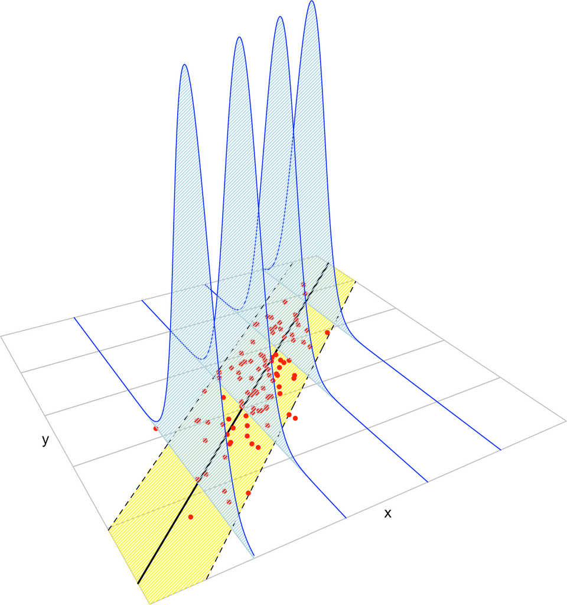

## Assumptions respected

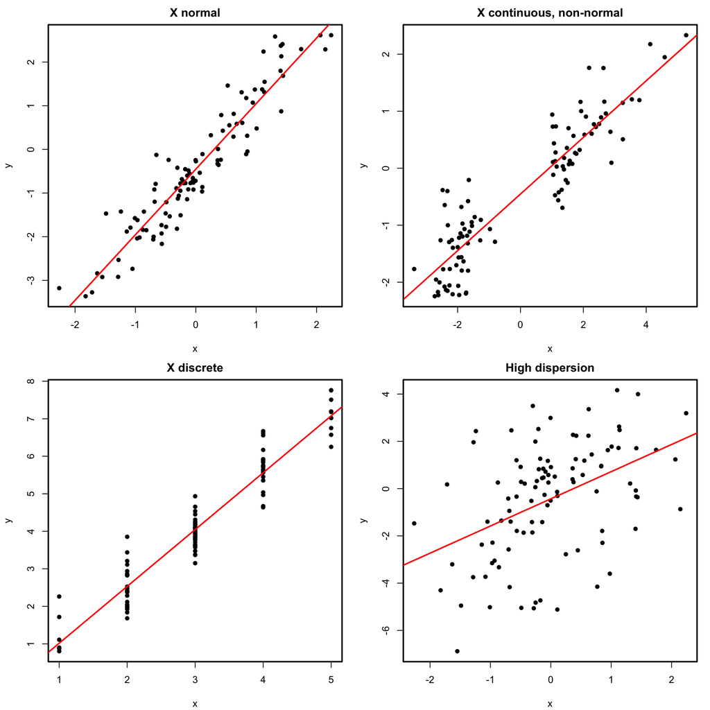

## Assumptions violated

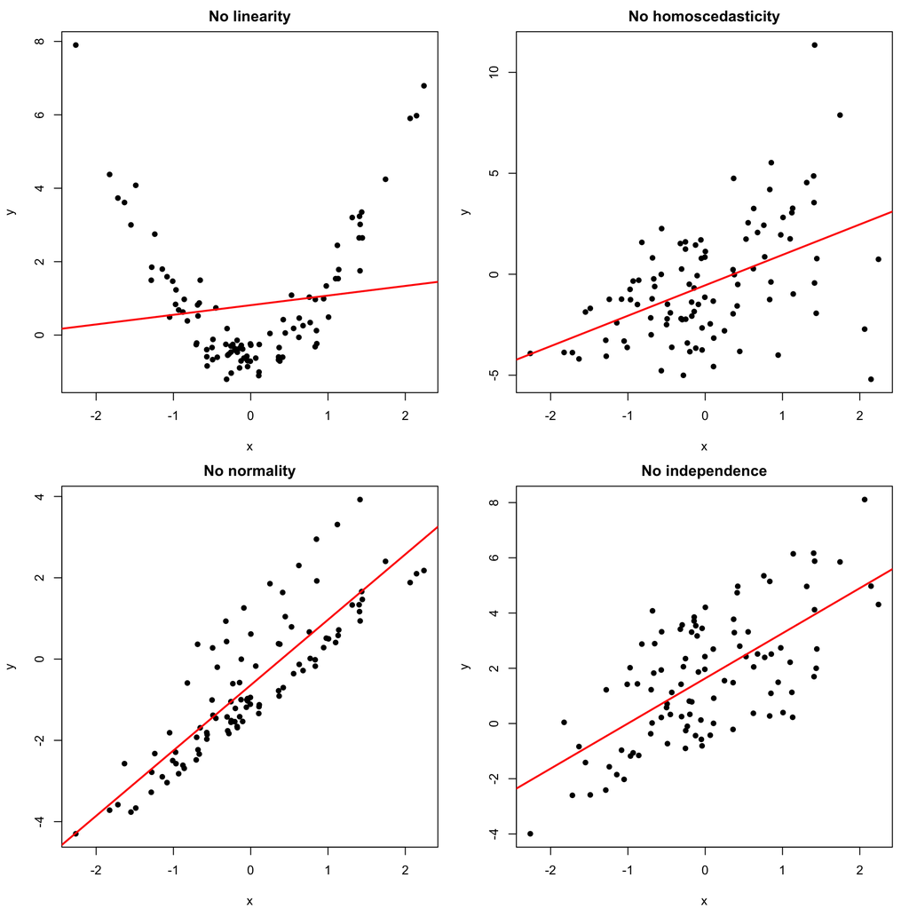

## Inference for the model coefficients

- The assumptions introduced in the previous section allow to specify what is the distribution of the random variables \(\hat{\beta}_0\) and \(\hat{\beta}_1\).
- As we will see, this is a key point for making inference on \(\beta_0\) and \(\beta_1\).
- The distributions are derived conditionally on the sample predictors \(X_1, \ldots, X_n\).
- In other words, we assume that the randomness of \(Y_i = \beta_0 + \beta_1 X_i + \epsilon_i, i = 1, 2, \ldots, n\), comes only from the error terms and not from the predictors.

## Distributions of the fitted coefficients

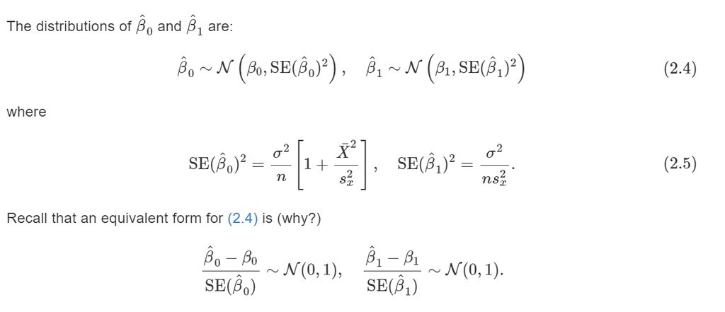

## Implications

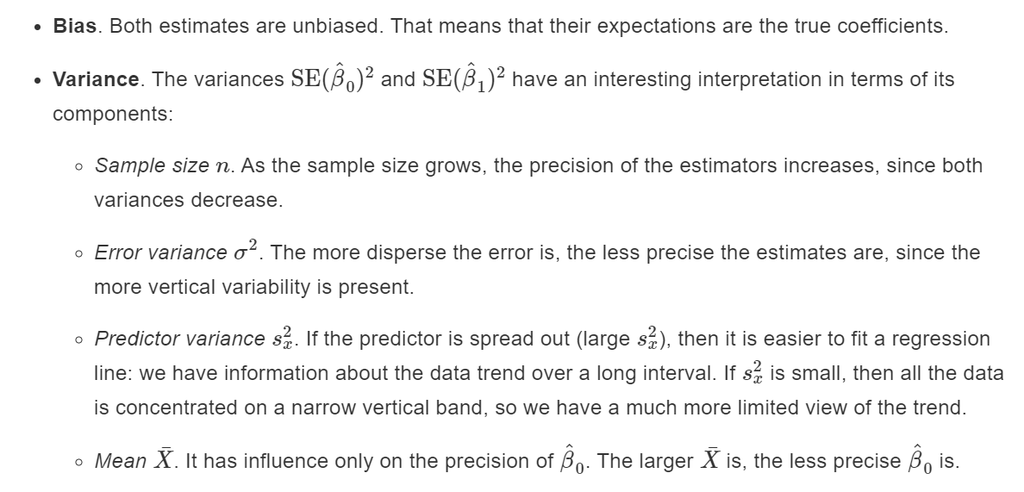

## Unknown \(\sigma^2\)

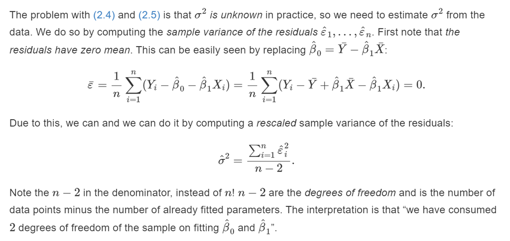

## Distribution

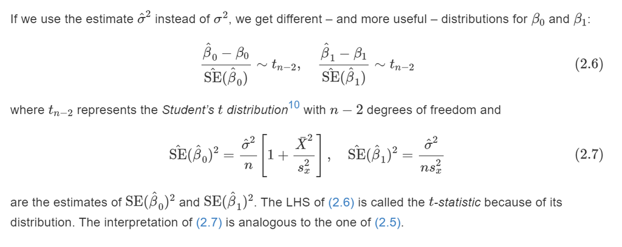

## Testing

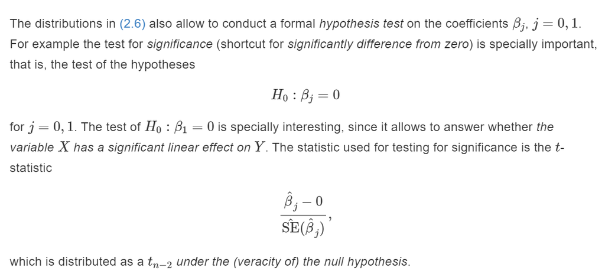

## Back to R output

```r
pisaLinearModel <- lm(MathMean ~ logGDPp, data = pisa)
summary(pisaLinearModel)
```

```
##
## Call:
## lm(formula = MathMean ~ logGDPp, data = pisa)
##
## Residuals:
##      Min       1Q   Median       3Q      Max
## -138.924  -29.109    1.381   20.239  176.166
##
## Coefficients:
##             Estimate Std. Error t value Pr(>|t|)
## (Intercept)   185.16      61.36   3.018  0.00369 **
## logGDPp        28.79       6.13   4.696 1.51e-05 ***
## ---
## Signif. codes:  0 '***' 0.001 '**' 0.01 '*' 0.05 '.' 0.1 ' ' 1
##
## Residual standard error: 47.48 on 62 degrees of freedom
## Multiple R-squared:  0.2624, Adjusted R-squared:  0.2505
## F-statistic: 22.06 on 1 and 62 DF,  p-value: 1.512e-05
```

## Interpretation

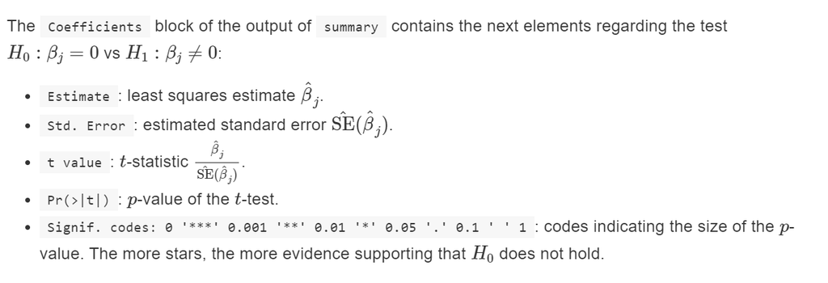

## ANOVA and model fit

- The variance of the error, \(\sigma^2\) plays a fundamental role in the inference for the model coefficients and prediction.
- In this section we will see how the variance of \(Y\) is decomposed into two parts, each one corresponding to the regression and to the error, respectively.
- This decomposition is called the ANalysis Of VAriance (ANOVA).
- This will help us in evaluating the model fit.

## ANOVA

- Before explaining ANOVA, it is important to recall an interesting result: the mean of the fitted values \(\hat{Y}_1, \ldots, \hat{Y}_n\) is the mean of \(Y_1, Y_2, \ldots, Y_n\).

\[ \frac{1}{n} \sum_{i=1}^{n} \hat{Y}_i = \bar{Y} \]

- Prove!

## ANOVA decomposition

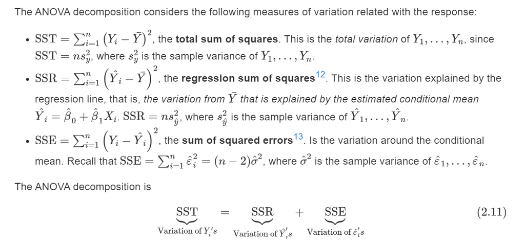

## ANOVA decomposition

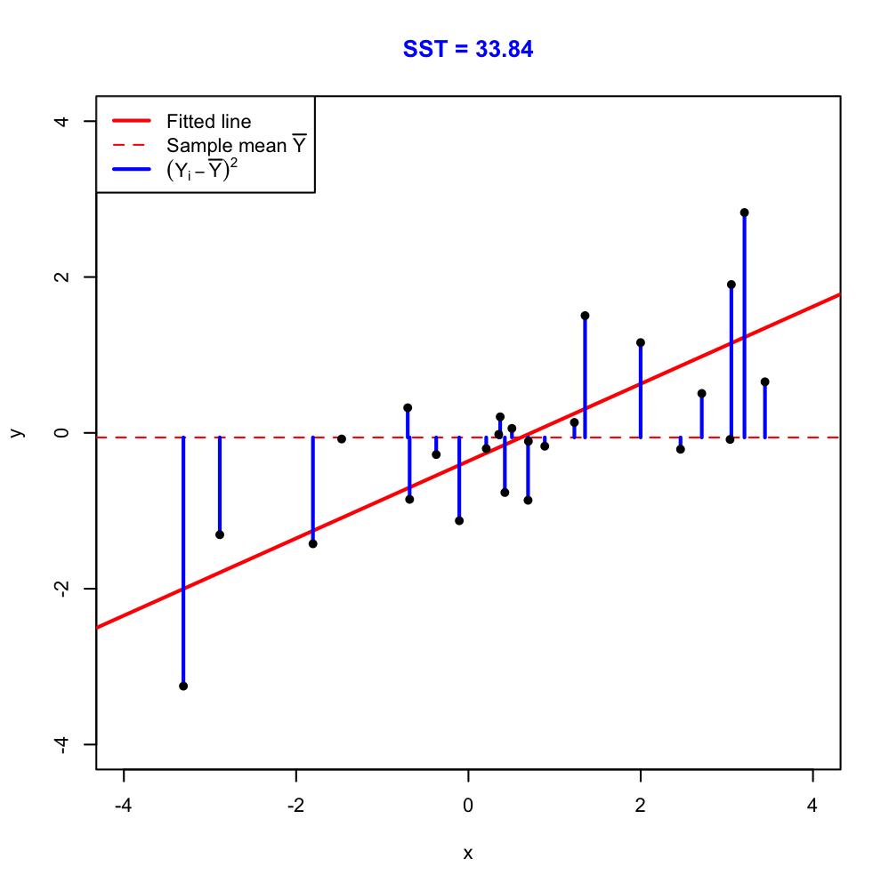

## ANOVA decomposition

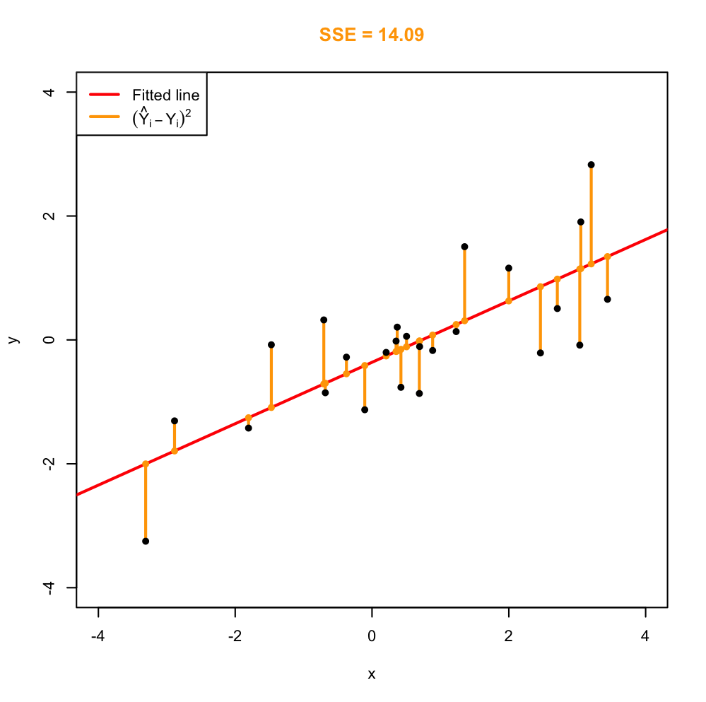

## ANOVA decomposition

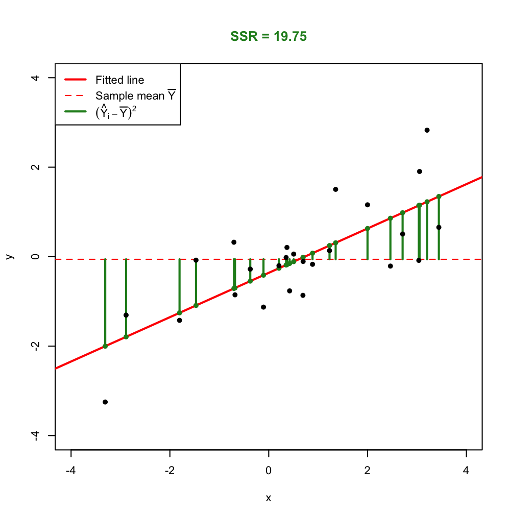

## ANOVA table

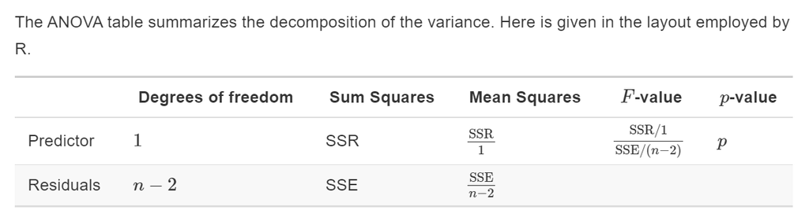

## In R

```r
# Fit a linear model
model <- lm(MathMean ~ ReadingMean, data = pisa)
anova(model)
```

```
## Analysis of Variance Table
##
## Response: MathMean
##             Df Sum Sq Mean Sq F value    Pr(>F)
## ReadingMean  1 174906  174906  744.73 < 2.2e-16 ***
## Residuals   62  14561     235
## ---
## Signif. codes:  0 '***' 0.001 '**' 0.01 '*' 0.05 '.' 0.1 ' ' 1
```

## Model fit: \(R^2\)

- The coefficient of determination \(R^2\) is closely related with the ANOVA decomposition. \[ R^2 = \frac{SSR}{SST} = \frac{SSR}{SSR + SSE} = \frac{SSR}{SSR + (n-2)\sigma^2} \]
- \(R^2\) measures the proportion of variation of the response variable \(Y\) that is explained by the predictor \(X\) through the regression.
- The proportion of total variation of \(Y\) that is not explained is \(1-R^2 = SSE/SST\).
- Intuitively, \(R^2\) measures the tightness of the data cloud around the regression line, since is related directly with \(\hat{\sigma}^2\).

## \(R^2\) and correlation

- For univariate regression, the \(R^2\) is related with the sample correlation coefficient: \[ R^2 = r^2_{xy} \]
- Interestingly, it also holds that: \[ R^2 = r_{y \hat{y}}^2, \]

that is the correlation coefficient between the observed responses \((Y_1, \ldots,Y_n)\) and the fitted values \((\hat{Y}_1, \ldots, \hat{Y}_n)\).

## Note that

- The equality \(R^2 = r_{y \hat{y}}^2\) is still true for the multiple linear regression, e.g.

\[ Y = \beta_0 + \beta_1 X_1 + \ldots + \beta_p X_p + \epsilon. \]

- On the contrary, there is no coefficient of correlation between three or more variables, so anything like \(r_{x_1x_2 \ldots x_p y}\) does not exist.
- Hence, \(R^2 = r^2_{xy}\) is a specific fact for simple linear regression.

## Check numerically

```r
# Responses generated following a linear model
set.seed(343567) # Fixes seed, allows to generate the same random data
x <- rnorm(50)
eps <- rnorm(50)
y <- -1 + 2 * x + eps

# Regression model
reg <- lm(y ~ x)
yHat <- reg$fitted.values

# Square of the correlation coefficient
cor(y, x)^2
```

```
## [1] 0.8166752
```

```r
cor(y, yHat)^2
```

```
## [1] 0.8166752
```

## Check numerically

```r
summary(reg)
```

```
##
## Call:
## lm(formula = y ~ x)
##
## Residuals:
##     Min      1Q  Median      3Q     Max
## -2.5834 -0.6015 -0.1466  0.6006  3.0419
##
## Coefficients:
##             Estimate Std. Error t value Pr(>|t|)
## (Intercept)  -0.9027     0.1503  -6.007 2.45e-07 ***
## x             2.1107     0.1443  14.623  < 2e-16 ***
## ---
## Signif. codes:  0 '***' 0.001 '**' 0.01 '*' 0.05 '.' 0.1 ' ' 1
##
## Residual standard error: 1.059 on 48 degrees of freedom
## Multiple R-squared:  0.8167, Adjusted R-squared:  0.8129
## F-statistic: 213.8 on 1 and 48 DF,  p-value: < 2.2e-16
```

## Two important points

- Two common sins regarding the use of \(R^2\).
  - Correctness. The linear model is built on certain assumptions, such as the ones we saw before. All the inferential results are based on these assumptions being true!. A model is formally correct whenever the assumptions on which is based are not violated in the data.
  - Usefulness. The usefulness of the model is a more subjective concept, but is usually measured by the accuracy on the prediction and explanation of the response \(Y\) by the predictor \(X\).
- For example, \(Y =0X + \epsilon\) is a valid linear model, but is completely useless for predicting \(Y\) from \(X\).

## ## Finally, don’t blindly follow R^2

Create data that: 1) does not follow a linear model 2) the error is heteroskedastic

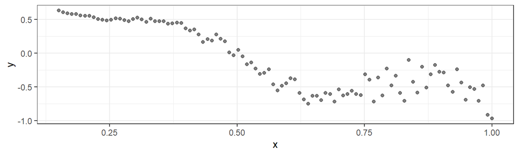

```r
x <- seq(0.15, 1, l = 100)
set.seed(123456)
eps <- rnorm(n = 100, sd = 0.25 * x^2)
y <- 1 - 2 * x * (1 + 0.25 * sin(4 * pi * x)) + eps

data.frame(y = y, x = x) %>%  ggplot(aes(x,y)) +
  geom_point(alpha = 0.5) + theme_bw()
```

## Great \(R^2\)

```r
# Great R^2!?
reg <- lm(y ~ x)
summary(reg)
```

```
##
## Call:
## lm(formula = y ~ x)
##
## Residuals:
##      Min       1Q   Median       3Q      Max
## -0.53525 -0.18020  0.02811  0.16882  0.46896
##
## Coefficients:
##             Estimate Std. Error t value Pr(>|t|)
## (Intercept)  0.87190    0.05860   14.88   <2e-16 ***
## x           -1.69268    0.09359  -18.09   <2e-16 ***
## ---
## Signif. codes:  0 '***' 0.001 '**' 0.01 '*' 0.05 '.' 0.1 ' ' 1
##
## Residual standard error: 0.232 on 98 degrees of freedom
## Multiple R-squared:  0.7695, Adjusted R-squared:  0.7671
## F-statistic: 327.1 on 1 and 98 DF,  p-value: < 2.2e-16
```

## Non-linear relationships

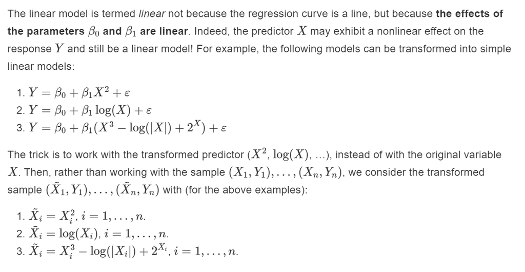